# Capstone Project

## Topic: Fandango Fake Reviews

### The Data

This is the data behind the story [Be Suspicious Of Online Movie Ratings, Especially Fandango’s](http://fivethirtyeight.com/features/fandango-movies-ratings/) openly available on 538's github: https://github.com/fivethirtyeight/data. There are two csv files, one with Fandango Stars and Displayed Ratings, and the other with aggregate data for movie ratings from other sites, like Metacritic,IMDB, and Rotten Tomatoes.

#### all_sites_scores.csv

| Column | Definition |
| --- | --- |
| FILM | The film in question |
| RottenTomatoes | The Rotten Tomatoes Tomatometer score for the film |
| RottenTomatoes_User | The Rotten Tomatoes user score for the film |
| Metacritic | The Metacritic critic score for the film |
| Metacritic_User | The Metacritic user score for the film |
| IMDB | The IMDb user score for the film |
| Metacritic_user_vote_count | The number of user votes the film had on Metacritic |
| IMDB_user_vote_count | The number of user votes the film had on IMDb |

**fandango_scrape.csv**

`fandango_scrape.csv` contains every film 538 pulled from Fandango.

| Column | Definiton |
| --- | --- |
| FILM | The movie |
| STARS | Number of stars presented on Fandango.com |
| RATING | The Fandango ratingValue for the film, as pulled from the HTML of each page. This is the actual average score the movie obtained. |
| VOTES | number of people who had reviewed the film at the time we pulled it. |

```python
import numpy as np
import pandas as pd
import matplotlib.pyplot as plt
import seaborn as sns
```

```python
fandango = pd.read_csv('./fandango_scrape.csv')
```

## Part Two: Exploring Fandango Displayed Scores versus True User Ratings

Let's first explore the Fandango ratings to see if our analysis agrees with the article's conclusion.

**TASK: Run the cell below to read in the fandango_scrape.csv file**

```python
fandango
```

|  | FILM | STARS | RATING | VOTES |
| --- | --- | --- | --- | --- |
| 0 | Fifty Shades of Grey (2015) | 4.0 | 3.9 | 34846 |
| 1 | Jurassic World (2015) | 4.5 | 4.5 | 34390 |
| 2 | American Sniper (2015) | 5.0 | 4.8 | 34085 |
| 3 | Furious 7 (2015) | 5.0 | 4.8 | 33538 |
| 4 | Inside Out (2015) | 4.5 | 4.5 | 15749 |
| ... | ... | ... | ... | ... |
| 499 | Valiyavan (2015) | 0.0 | 0.0 | 0 |
| 500 | WWE SummerSlam 2015 (2015) | 0.0 | 0.0 | 0 |
| 501 | Yagavarayinum Naa Kaakka (2015) | 0.0 | 0.0 | 0 |
| 502 | Yesterday, Today and Tomorrow (1964) | 0.0 | 0.0 | 0 |
| 503 | Zarafa (2012) | 0.0 | 0.0 | 0 |

504 rows × 4 columns

```python
fandango.info()
```

```
<class 'pandas.core.frame.DataFrame'>
RangeIndex: 504 entries, 0 to 503
Data columns (total 4 columns):
 #   Column  Non-Null Count  Dtype
---  ------  --------------  -----
 0   FILM    504 non-null    object
 1   STARS   504 non-null    float64
 2   RATING  504 non-null    float64
 3   VOTES   504 non-null    int64
dtypes: float64(2), int64(1), object(1)
memory usage: 15.9+ KB
```

```python
fandango.describe()
```

|  | STARS | RATING | VOTES |
| --- | --- | --- | --- |
| count | 504.000000 | 504.000000 | 504.000000 |
| mean | 3.558532 | 3.375794 | 1147.863095 |
| std | 1.563133 | 1.491223 | 3830.583136 |
| min | 0.000000 | 0.000000 | 0.000000 |
| 25% | 3.500000 | 3.100000 | 3.000000 |
| 50% | 4.000000 | 3.800000 | 18.500000 |
| 75% | 4.500000 | 4.300000 | 189.750000 |
| max | 5.000000 | 5.000000 | 34846.000000 |

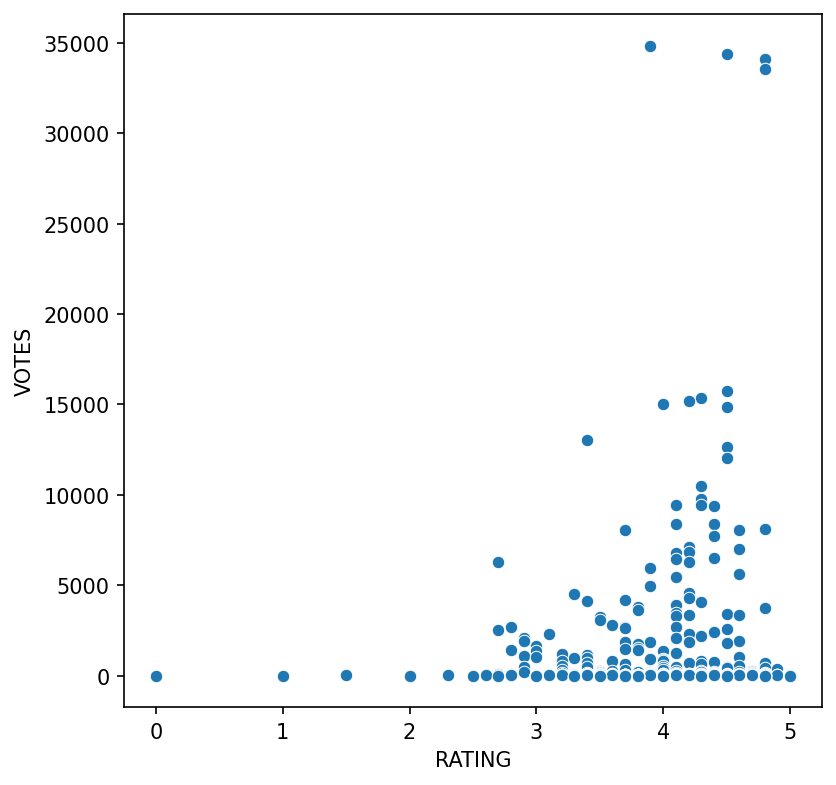

```python
plt.figure(figsize=(6,6), dpi=150)
sns.scatterplot(data=fandango, x='RATING', y='VOTES')
plt.show()
```

```python
fandango.corr()
```

|  | STARS | RATING | VOTES |
| --- | --- | --- | --- |
| STARS | 1.000000 | 0.994696 | 0.164218 |
| RATING | 0.994696 | 1.000000 | 0.163764 |
| VOTES | 0.164218 | 0.163764 | 1.000000 |

```python
def spl(s):
    x = s.split(' ')
    return x[-1]
```

```python
fandango['YEAR'] = fandango['FILM'].apply(spl)
```

```python
fandango.head()
```

|  | FILM | STARS | RATING | VOTES | YEAR |
| --- | --- | --- | --- | --- | --- |
| 0 | Fifty Shades of Grey (2015) | 4.0 | 3.9 | 34846 | (2015) |
| 1 | Jurassic World (2015) | 4.5 | 4.5 | 34390 | (2015) |
| 2 | American Sniper (2015) | 5.0 | 4.8 | 34085 | (2015) |
| 3 | Furious 7 (2015) | 5.0 | 4.8 | 33538 | (2015) |
| 4 | Inside Out (2015) | 4.5 | 4.5 | 15749 | (2015) |

```python
fandango['YEAR'] = fandango['YEAR'].str.slice(start=1, stop=5)
```

```python
fandango.head()
```

|  | FILM | STARS | RATING | VOTES | YEAR |
| --- | --- | --- | --- | --- | --- |
| 0 | Fifty Shades of Grey (2015) | 4.0 | 3.9 | 34846 | 2015 |
| 1 | Jurassic World (2015) | 4.5 | 4.5 | 34390 | 2015 |
| 2 | American Sniper (2015) | 5.0 | 4.8 | 34085 | 2015 |
| 3 | Furious 7 (2015) | 5.0 | 4.8 | 33538 | 2015 |
| 4 | Inside Out (2015) | 4.5 | 4.5 | 15749 | 2015 |

```python
fandango['MOVIES_PER_YEAR'] = fandango['YEAR'].value_counts()
```

```python
fandango = fandango.drop('MOVIES_PER_YEAR', axis=1)
```

```python
fandango.head()
```

|  | FILM | STARS | RATING | VOTES | YEAR |
| --- | --- | --- | --- | --- | --- |
| 0 | Fifty Shades of Grey (2015) | 4.0 | 3.9 | 34846 | 2015 |
| 1 | Jurassic World (2015) | 4.5 | 4.5 | 34390 | 2015 |
| 2 | American Sniper (2015) | 5.0 | 4.8 | 34085 | 2015 |
| 3 | Furious 7 (2015) | 5.0 | 4.8 | 33538 | 2015 |
| 4 | Inside Out (2015) | 4.5 | 4.5 | 15749 | 2015 |

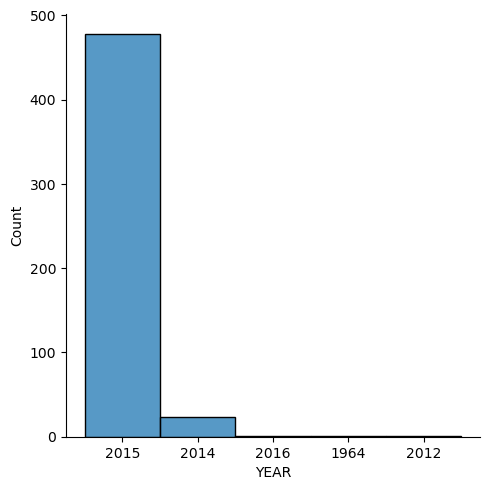

```python
plt.figure(figsize=(10,6), dpi=150)
sns.displot(data=fandango, x='YEAR')
plt.show()
```

```python
fandango.sort_values(ascending=False, by='VOTES')
```

|  | FILM | STARS | RATING | VOTES | YEAR |
| --- | --- | --- | --- | --- | --- |
| 0 | Fifty Shades of Grey (2015) | 4.0 | 3.9 | 34846 | 2015 |
| 1 | Jurassic World (2015) | 4.5 | 4.5 | 34390 | 2015 |
| 2 | American Sniper (2015) | 5.0 | 4.8 | 34085 | 2015 |
| 3 | Furious 7 (2015) | 5.0 | 4.8 | 33538 | 2015 |
| 4 | Inside Out (2015) | 4.5 | 4.5 | 15749 | 2015 |
| ... | ... | ... | ... | ... | ... |
| 463 | La leon (2015) | 0.0 | 0.0 | 0 | 2015 |
| 464 | La passion d'Augustine (2015) | 0.0 | 0.0 | 0 | 2015 |
| 465 | Le gaucher (2015) | 0.0 | 0.0 | 0 | 2015 |
| 466 | Le monde de demain (2015) | 0.0 | 0.0 | 0 | 2015 |
| 503 | Zarafa (2012) | 0.0 | 0.0 | 0 | 2012 |

504 rows × 5 columns

**As noted in the article, due to HTML and star rating displays, the true user rating may be slightly different than the rating shown to a user. Let's visualize this difference in distributions.**

```python
(fandango['VOTES'] == 0).value_counts()
```

```
False    435
True      69
Name: VOTES, dtype: int64
```

```python
fandango2 = fandango.loc[(fandango['VOTES'] != 0)]
```

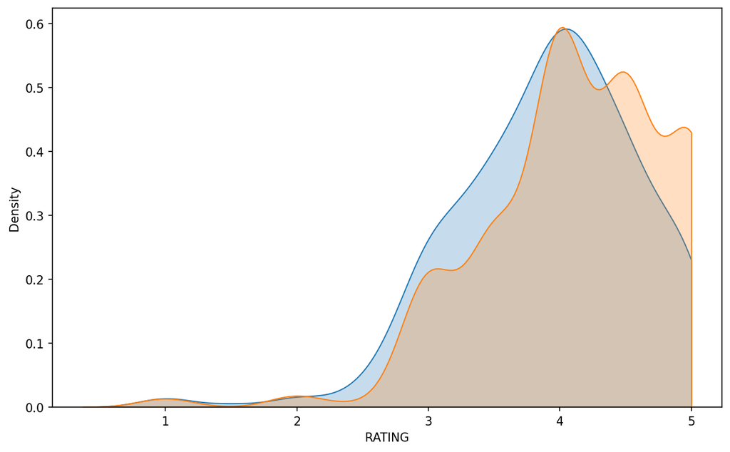

```python
plt.figure(figsize=(10,6), dpi=150)
sns.kdeplot(data=fandango2, x='RATING', shade=True, clip=(0,5))
sns.kdeplot(data=fandango2, x='STARS', shade=True, clip=(0,5))

plt.show()
```

```python
fandango2['STARS_DIFF'] = fandango['STARS']-fandango['RATING']
fandango2['STARS_DIFF'] = fandango2['STARS_DIFF'].round(2)
```

```python
fandango2.head()
```

|  | FILM | STARS | RATING | VOTES | YEAR | STARS_DIFF |
| --- | --- | --- | --- | --- | --- | --- |
| 0 | Fifty Shades of Grey (2015) | 4.0 | 3.9 | 34846 | 2015 | 0.1 |
| 1 | Jurassic World (2015) | 4.5 | 4.5 | 34390 | 2015 | 0.0 |
| 2 | American Sniper (2015) | 5.0 | 4.8 | 34085 | 2015 | 0.2 |
| 3 | Furious 7 (2015) | 5.0 | 4.8 | 33538 | 2015 | 0.2 |
| 4 | Inside Out (2015) | 4.5 | 4.5 | 15749 | 2015 | 0.0 |

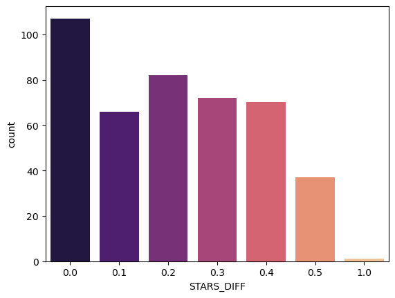

```python
sns.countplot(data=fandango2, x='STARS_DIFF', palette='magma', )
plt.show()
```

```python
fandango2[fandango2.STARS_DIFF ==  fandango2.STARS_DIFF.max()]
```

|  | FILM | STARS | RATING | VOTES | YEAR | STARS_DIFF |
| --- | --- | --- | --- | --- | --- | --- |
| 381 | Turbo Kid (2015) | 5.0 | 4.0 | 2 | 2015 | 1.0 |

## Part Three: Comparison of Fandango Ratings to Other Sites

Let's now compare the scores from Fandango to other movies sites and see how they compare.

```python
all_sites = pd.read_csv('all_sites_scores.csv')
```

```python
all_sites
```

|  | FILM | RottenTomatoes | RottenTomatoes_User | Metacritic | Metacritic_User | IMDB | Metacritic_user_vote_count | IMDB_user_vote_count |
| --- | --- | --- | --- | --- | --- | --- | --- | --- |
| 0 | Avengers: Age of Ultron (2015) | 74 | 86 | 66 | 7.1 | 7.8 | 1330 | 271107 |
| 1 | Cinderella (2015) | 85 | 80 | 67 | 7.5 | 7.1 | 249 | 65709 |
| 2 | Ant-Man (2015) | 80 | 90 | 64 | 8.1 | 7.8 | 627 | 103660 |
| 3 | Do You Believe? (2015) | 18 | 84 | 22 | 4.7 | 5.4 | 31 | 3136 |
| 4 | Hot Tub Time Machine 2 (2015) | 14 | 28 | 29 | 3.4 | 5.1 | 88 | 19560 |
| ... | ... | ... | ... | ... | ... | ... | ... | ... |
| 141 | Mr. Holmes (2015) | 87 | 78 | 67 | 7.9 | 7.4 | 33 | 7367 |
| 142 | '71 (2015) | 97 | 82 | 83 | 7.5 | 7.2 | 60 | 24116 |
| 143 | Two Days, One Night (2014) | 97 | 78 | 89 | 8.8 | 7.4 | 123 | 24345 |
| 144 | Gett: The Trial of Viviane Amsalem (2015) | 100 | 81 | 90 | 7.3 | 7.8 | 19 | 1955 |
| 145 | Kumiko, The Treasure Hunter (2015) | 87 | 63 | 68 | 6.4 | 6.7 | 19 | 5289 |

146 rows × 8 columns

```python
all_sites.info()
```

```
<class 'pandas.core.frame.DataFrame'>
RangeIndex: 146 entries, 0 to 145
Data columns (total 8 columns):
 #   Column                      Non-Null Count  Dtype
---  ------                      --------------  -----
 0   FILM                        146 non-null    object
 1   RottenTomatoes              146 non-null    int64
 2   RottenTomatoes_User         146 non-null    int64
 3   Metacritic                  146 non-null    int64
 4   Metacritic_User             146 non-null    float64
 5   IMDB                        146 non-null    float64
 6   Metacritic_user_vote_count  146 non-null    int64
 7   IMDB_user_vote_count        146 non-null    int64
dtypes: float64(2), int64(5), object(1)
memory usage: 9.2+ KB
```

### Rotten Tomatoes

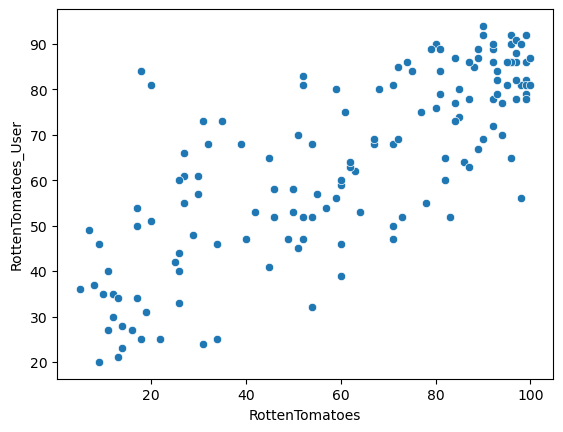

```python
sns.scatterplot(data=all_sites, x='RottenTomatoes', y='RottenTomatoes_User')
```

```python
all_sites['ROTTEN_TOM_DIFF'] = all_sites['RottenTomatoes'] - all_sites['RottenTomatoes_User']
```

```python
all_sites.head()
```

|  | FILM | RottenTomatoes | RottenTomatoes_User | Metacritic | Metacritic_User | IMDB | Metacritic_user_vote_count | IMDB_user_vote_count | ROTTEN_TOM_DIFF |
| --- | --- | --- | --- | --- | --- | --- | --- | --- | --- |
| 0 | Avengers: Age of Ultron (2015) | 74 | 86 | 66 | 7.1 | 7.8 | 1330 | 271107 | -12 |
| 1 | Cinderella (2015) | 85 | 80 | 67 | 7.5 | 7.1 | 249 | 65709 | 5 |
| 2 | Ant-Man (2015) | 80 | 90 | 64 | 8.1 | 7.8 | 627 | 103660 | -10 |
| 3 | Do You Believe? (2015) | 18 | 84 | 22 | 4.7 | 5.4 | 31 | 3136 | -66 |
| 4 | Hot Tub Time Machine 2 (2015) | 14 | 28 | 29 | 3.4 | 5.1 | 88 | 19560 | -14 |

```python
all_sites['ROTTEN_TOM_DIFF'].abs().mean()
```

```
15.095890410958905
```

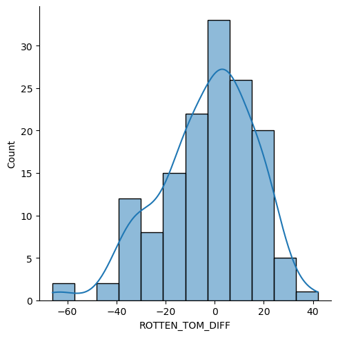

```python
plt.figure(figsize=(4,10), dpi=150)
sns.displot(data=all_sites, x='ROTTEN_TOM_DIFF', kde=True)
plt.show()
```

```python
all_sites['ROTTEN_TOM_DIFF_ABS'] = all_sites['ROTTEN_TOM_DIFF'].abs()
```

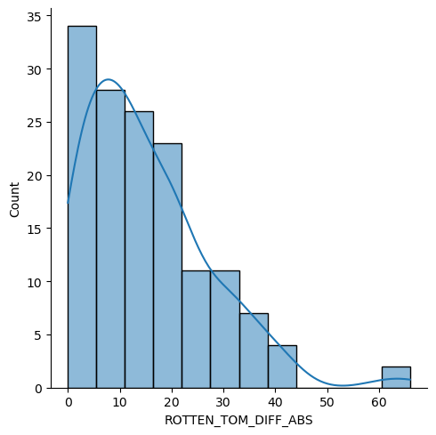

```python
sns.displot(data=all_sites, x='ROTTEN_TOM_DIFF_ABS', kde=True)
```

```python
all_sites['ROTTEN_TOM_DIFF'].sort_index(inplace=True)
```

```python
all_sites_cpy = all_sites
```

```python
all_sites_cpy.nsmallest(5, 'ROTTEN_TOM_DIFF')
```

|  | FILM | RottenTomatoes | RottenTomatoes_User | Metacritic | Metacritic_User | IMDB | Metacritic_user_vote_count | IMDB_user_vote_count | ROTTEN_TOM_DIFF | ROTTEN_TOM_DIFF_ABS |
| --- | --- | --- | --- | --- | --- | --- | --- | --- | --- | --- |
| 3 | Do You Believe? (2015) | 18 | 84 | 22 | 4.7 | 5.4 | 31 | 3136 | -66 | 66 |
| 85 | Little Boy (2015) | 20 | 81 | 30 | 5.9 | 7.4 | 38 | 5927 | -61 | 61 |
| 105 | Hitman: Agent 47 (2015) | 7 | 49 | 28 | 3.3 | 5.9 | 67 | 4260 | -42 | 42 |
| 134 | The Longest Ride (2015) | 31 | 73 | 33 | 4.8 | 7.2 | 49 | 25214 | -42 | 42 |
| 125 | The Wedding Ringer (2015) | 27 | 66 | 35 | 3.3 | 6.7 | 126 | 37292 | -39 | 39 |

```python
all_sites_cpy.nlargest(5, 'ROTTEN_TOM_DIFF')
```

|  | FILM | RottenTomatoes | RottenTomatoes_User | Metacritic | Metacritic_User | IMDB | Metacritic_user_vote_count | IMDB_user_vote_count | ROTTEN_TOM_DIFF | ROTTEN_TOM_DIFF_ABS |
| --- | --- | --- | --- | --- | --- | --- | --- | --- | --- | --- |
| 69 | Mr. Turner (2014) | 98 | 56 | 94 | 6.6 | 6.9 | 98 | 13296 | 42 | 42 |
| 112 | It Follows (2015) | 96 | 65 | 83 | 7.5 | 6.9 | 551 | 64656 | 31 | 31 |
| 115 | While We're Young (2015) | 83 | 52 | 76 | 6.7 | 6.4 | 65 | 17647 | 31 | 31 |
| 37 | Welcome to Me (2015) | 71 | 47 | 67 | 6.9 | 5.9 | 33 | 8301 | 24 | 24 |
| 40 | I'll See You In My Dreams (2015) | 94 | 70 | 75 | 6.9 | 6.9 | 14 | 1151 | 24 | 24 |

### MetaCritic

Now let's take a quick look at the ratings from MetaCritic. Metacritic also shows an average user rating versus their official displayed rating.

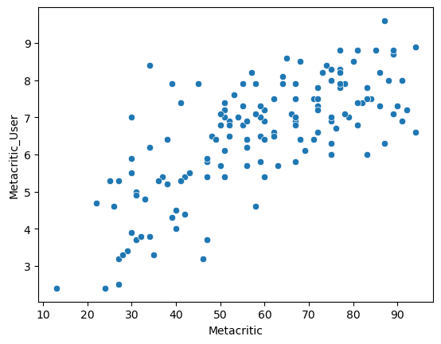

```python
sns.scatterplot(data=all_sites_cpy, x='Metacritic', y='Metacritic_User')
```

### IMDB

Finally let's explore IMDB. Notice that both Metacritic and IMDB report back vote counts. Let's analyze the most popular movies.

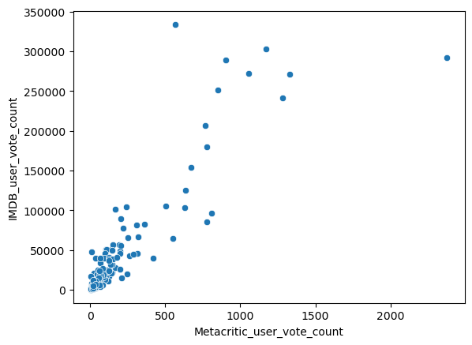

```python
sns.scatterplot(data=all_sites_cpy, x='Metacritic_user_vote_count', y='IMDB_user_vote_count')
```

#### Highest user voted movie on IMDB

```python
all_sites_cpy.nlargest(1, 'IMDB_user_vote_count')
```

|  | FILM | RottenTomatoes | RottenTomatoes_User | Metacritic | Metacritic_User | IMDB | Metacritic_user_vote_count | IMDB_user_vote_count | ROTTEN_TOM_DIFF | ROTTEN_TOM_DIFF_ABS |
| --- | --- | --- | --- | --- | --- | --- | --- | --- | --- | --- |
| 14 | The Imitation Game (2014) | 90 | 92 | 73 | 8.2 | 8.1 | 566 | 334164 | -2 | 2 |

#### Highest user voted movie on Metacritic

```python
all_sites_cpy.nlargest(1, 'Metacritic_user_vote_count')
```

|  | FILM | RottenTomatoes | RottenTomatoes_User | Metacritic | Metacritic_User | IMDB | Metacritic_user_vote_count | IMDB_user_vote_count | ROTTEN_TOM_DIFF | ROTTEN_TOM_DIFF_ABS |
| --- | --- | --- | --- | --- | --- | --- | --- | --- | --- | --- |
| 88 | Mad Max: Fury Road (2015) | 97 | 88 | 89 | 8.7 | 8.3 | 2375 | 292023 | 9 | 9 |

### Fandago Scores vs Other Sites Scores

```python
finalDf =  pd.merge(left=all_sites_cpy, right=fandango2, how='inner', on='FILM')
```

```python
finalDf
```

|  | FILM | RottenTomatoes | RottenTomatoes_User | Metacritic | Metacritic_User | IMDB | Metacritic_user_vote_count | IMDB_user_vote_count | ROTTEN_TOM_DIFF | ROTTEN_TOM_DIFF_ABS | STARS | RATING | VOTES | YEAR | STARS_DIFF |
| --- | --- | --- | --- | --- | --- | --- | --- | --- | --- | --- | --- | --- | --- | --- | --- |
| 0 | Avengers: Age of Ultron (2015) | 74 | 86 | 66 | 7.1 | 7.8 | 1330 | 271107 | -12 | 12 | 5.0 | 4.5 | 14846 | 2015 | 0.5 |
| 1 | Cinderella (2015) | 85 | 80 | 67 | 7.5 | 7.1 | 249 | 65709 | 5 | 5 | 5.0 | 4.5 | 12640 | 2015 | 0.5 |
| 2 | Ant-Man (2015) | 80 | 90 | 64 | 8.1 | 7.8 | 627 | 103660 | -10 | 10 | 5.0 | 4.5 | 12055 | 2015 | 0.5 |
| 3 | Do You Believe? (2015) | 18 | 84 | 22 | 4.7 | 5.4 | 31 | 3136 | -66 | 66 | 5.0 | 4.5 | 1793 | 2015 | 0.5 |
| 4 | Hot Tub Time Machine 2 (2015) | 14 | 28 | 29 | 3.4 | 5.1 | 88 | 19560 | -14 | 14 | 3.5 | 3.0 | 1021 | 2015 | 0.5 |
| ... | ... | ... | ... | ... | ... | ... | ... | ... | ... | ... | ... | ... | ... | ... | ... |
| 140 | Mr. Holmes (2015) | 87 | 78 | 67 | 7.9 | 7.4 | 33 | 7367 | 9 | 9 | 4.0 | 4.0 | 1348 | 2015 | 0.0 |
| 141 | '71 (2015) | 97 | 82 | 83 | 7.5 | 7.2 | 60 | 24116 | 15 | 15 | 3.5 | 3.5 | 192 | 2015 | 0.0 |
| 142 | Two Days, One Night (2014) | 97 | 78 | 89 | 8.8 | 7.4 | 123 | 24345 | 19 | 19 | 3.5 | 3.5 | 118 | 2014 | 0.0 |
| 143 | Gett: The Trial of Viviane Amsalem (2015) | 100 | 81 | 90 | 7.3 | 7.8 | 19 | 1955 | 19 | 19 | 3.5 | 3.5 | 59 | 2015 | 0.0 |
| 144 | Kumiko, The Treasure Hunter (2015) | 87 | 63 | 68 | 6.4 | 6.7 | 19 | 5289 | 24 | 24 | 3.5 | 3.5 | 41 | 2015 | 0.0 |

145 rows × 15 columns

```python
finalDf.info()
```

```
<class 'pandas.core.frame.DataFrame'>
Int64Index: 145 entries, 0 to 144
Data columns (total 15 columns):
 #   Column                      Non-Null Count  Dtype
---  ------                      --------------  -----
 0   FILM                        145 non-null    object
 1   RottenTomatoes              145 non-null    int64
 2   RottenTomatoes_User         145 non-null    int64
 3   Metacritic                  145 non-null    int64
 4   Metacritic_User             145 non-null    float64
 5   IMDB                        145 non-null    float64
 6   Metacritic_user_vote_count  145 non-null    int64
 7   IMDB_user_vote_count        145 non-null    int64
 8   ROTTEN_TOM_DIFF             145 non-null    int64
 9   ROTTEN_TOM_DIFF_ABS         145 non-null    int64
 10  STARS                       145 non-null    float64
 11  RATING                      145 non-null    float64
 12  VOTES                       145 non-null    int64
 13  YEAR                        145 non-null    object
 14  STARS_DIFF                  145 non-null    float64
dtypes: float64(5), int64(8), object(2)
memory usage: 18.1+ KB
```

```python
def normalized(n):
    if(n<=10):
        n = n/2
    elif(n>10 and n<=100):
        n = n/20
    else:
        n = n/200
    return n
```

```python
finalDf['RT_norm'] = finalDf['RottenTomatoes'].apply(normalized)
finalDf['RTU_norm'] = finalDf['RottenTomatoes_User'].apply(normalized)
finalDf['Meta_norm'] = finalDf['Metacritic'].apply(normalized)
finalDf['Meta_U_norm'] = finalDf['Metacritic_User'].apply(normalized)
finalDf['IMDB_Norm'] = finalDf['IMDB'].apply(normalized)
```

```python
finalDf
```

|  | FILM | RottenTomatoes | RottenTomatoes_User | Metacritic | Metacritic_User | IMDB | Metacritic_user_vote_count | IMDB_user_vote_count | ROTTEN_TOM_DIFF | ROTTEN_TOM_DIFF_ABS | STARS | RATING | VOTES | YEAR | STARS_DIFF | RT_norm | RTU_norm | Meta_norm | Meta_U_norm | IMDB_Norm |
| --- | --- | --- | --- | --- | --- | --- | --- | --- | --- | --- | --- | --- | --- | --- | --- | --- | --- | --- | --- | --- |
| 0 | Avengers: Age of Ultron (2015) | 74 | 86 | 66 | 7.1 | 7.8 | 1330 | 271107 | -12 | 12 | 5.0 | 4.5 | 14846 | 2015 | 0.5 | 3.70 | 4.30 | 3.30 | 3.55 | 3.90 |
| 1 | Cinderella (2015) | 85 | 80 | 67 | 7.5 | 7.1 | 249 | 65709 | 5 | 5 | 5.0 | 4.5 | 12640 | 2015 | 0.5 | 4.25 | 4.00 | 3.35 | 3.75 | 3.55 |
| 2 | Ant-Man (2015) | 80 | 90 | 64 | 8.1 | 7.8 | 627 | 103660 | -10 | 10 | 5.0 | 4.5 | 12055 | 2015 | 0.5 | 4.00 | 4.50 | 3.20 | 4.05 | 3.90 |
| 3 | Do You Believe? (2015) | 18 | 84 | 22 | 4.7 | 5.4 | 31 | 3136 | -66 | 66 | 5.0 | 4.5 | 1793 | 2015 | 0.5 | 0.90 | 4.20 | 1.10 | 2.35 | 2.70 |
| 4 | Hot Tub Time Machine 2 (2015) | 14 | 28 | 29 | 3.4 | 5.1 | 88 | 19560 | -14 | 14 | 3.5 | 3.0 | 1021 | 2015 | 0.5 | 0.70 | 1.40 | 1.45 | 1.70 | 2.55 |
| ... | ... | ... | ... | ... | ... | ... | ... | ... | ... | ... | ... | ... | ... | ... | ... | ... | ... | ... | ... | ... |
| 140 | Mr. Holmes (2015) | 87 | 78 | 67 | 7.9 | 7.4 | 33 | 7367 | 9 | 9 | 4.0 | 4.0 | 1348 | 2015 | 0.0 | 4.35 | 3.90 | 3.35 | 3.95 | 3.70 |
| 141 | '71 (2015) | 97 | 82 | 83 | 7.5 | 7.2 | 60 | 24116 | 15 | 15 | 3.5 | 3.5 | 192 | 2015 | 0.0 | 4.85 | 4.10 | 4.15 | 3.75 | 3.60 |
| 142 | Two Days, One Night (2014) | 97 | 78 | 89 | 8.8 | 7.4 | 123 | 24345 | 19 | 19 | 3.5 | 3.5 | 118 | 2014 | 0.0 | 4.85 | 3.90 | 4.45 | 4.40 | 3.70 |
| 143 | Gett: The Trial of Viviane Amsalem (2015) | 100 | 81 | 90 | 7.3 | 7.8 | 19 | 1955 | 19 | 19 | 3.5 | 3.5 | 59 | 2015 | 0.0 | 5.00 | 4.05 | 4.50 | 3.65 | 3.90 |
| 144 | Kumiko, The Treasure Hunter (2015) | 87 | 63 | 68 | 6.4 | 6.7 | 19 | 5289 | 24 | 24 | 3.5 | 3.5 | 41 | 2015 | 0.0 | 4.35 | 3.15 | 3.40 | 3.20 | 3.35 |

145 rows × 20 columns

```python
finalNorm = pd.DataFrame(data=[finalDf['STARS'], finalDf['RATING'], finalDf['RT_norm'], finalDf['RTU_norm'], finalDf['Meta_norm'], finalDf['Meta_U_norm'], finalDf['IMDB_Norm']])
```

### Creating a dataframe only using the normalized columns

```python
finalNorm
```

|  | 0 | 1 | 2 | 3 | 4 | 5 | 6 | 7 | 8 | 9 | ... | 135 | 136 | 137 | 138 | 139 | 140 | 141 | 142 | 143 | 144 |
| --- | --- | --- | --- | --- | --- | --- | --- | --- | --- | --- | --- | --- | --- | --- | --- | --- | --- | --- | --- | --- | --- |
| STARS | 5.00 | 5.00 | 5.00 | 5.00 | 3.50 | 4.50 | 4.00 | 4.00 | 4.50 | 4.50 | ... | 3.00 | 4.00 | 4.50 | 3.00 | 4.50 | 4.00 | 3.50 | 3.50 | 3.50 | 3.50 |
| RATING | 4.50 | 4.50 | 4.50 | 4.50 | 3.00 | 4.00 | 3.50 | 3.50 | 4.00 | 4.00 | ... | 3.00 | 4.00 | 4.50 | 3.00 | 4.50 | 4.00 | 3.50 | 3.50 | 3.50 | 3.50 |
| RT_norm | 3.70 | 4.25 | 4.00 | 0.90 | 0.70 | 3.15 | 2.10 | 4.30 | 4.95 | 4.45 | ... | 1.10 | 3.85 | 2.60 | 0.90 | 4.90 | 4.35 | 4.85 | 4.85 | 5.00 | 4.35 |
| RTU_norm | 4.30 | 4.00 | 4.50 | 4.20 | 1.40 | 3.10 | 2.65 | 3.20 | 4.10 | 4.35 | ... | 1.25 | 3.75 | 4.15 | 1.25 | 4.50 | 3.90 | 4.10 | 3.90 | 4.05 | 3.15 |
| Meta_norm | 3.30 | 3.35 | 3.20 | 1.10 | 1.45 | 2.50 | 2.65 | 4.05 | 4.05 | 4.00 | ... | 2.10 | 2.90 | 2.50 | 1.80 | 4.70 | 3.35 | 4.15 | 4.45 | 4.50 | 3.40 |
| Meta_U_norm | 3.55 | 3.75 | 4.05 | 2.35 | 1.70 | 3.40 | 3.80 | 3.40 | 4.40 | 4.25 | ... | 2.20 | 3.55 | 3.55 | 2.65 | 4.45 | 3.95 | 3.75 | 4.40 | 3.65 | 3.20 |
| IMDB_Norm | 3.90 | 3.55 | 3.90 | 2.70 | 2.55 | 3.60 | 3.45 | 3.25 | 3.70 | 3.90 | ... | 2.45 | 3.55 | 3.60 | 2.70 | 4.30 | 3.70 | 3.60 | 3.70 | 3.90 | 3.35 |

7 rows × 145 columns

```python
finalNorm = finalNorm.transpose()
```

```python
finalNorm
```

|  | STARS | RATING | RT_norm | RTU_norm | Meta_norm | Meta_U_norm | IMDB_Norm |
| --- | --- | --- | --- | --- | --- | --- | --- |
| 0 | 5.0 | 4.5 | 3.70 | 4.30 | 3.30 | 3.55 | 3.90 |
| 1 | 5.0 | 4.5 | 4.25 | 4.00 | 3.35 | 3.75 | 3.55 |
| 2 | 5.0 | 4.5 | 4.00 | 4.50 | 3.20 | 4.05 | 3.90 |
| 3 | 5.0 | 4.5 | 0.90 | 4.20 | 1.10 | 2.35 | 2.70 |
| 4 | 3.5 | 3.0 | 0.70 | 1.40 | 1.45 | 1.70 | 2.55 |
| ... | ... | ... | ... | ... | ... | ... | ... |
| 140 | 4.0 | 4.0 | 4.35 | 3.90 | 3.35 | 3.95 | 3.70 |
| 141 | 3.5 | 3.5 | 4.85 | 4.10 | 4.15 | 3.75 | 3.60 |
| 142 | 3.5 | 3.5 | 4.85 | 3.90 | 4.45 | 4.40 | 3.70 |
| 143 | 3.5 | 3.5 | 5.00 | 4.05 | 4.50 | 3.65 | 3.90 |
| 144 | 3.5 | 3.5 | 4.35 | 3.15 | 3.40 | 3.20 | 3.35 |

145 rows × 7 columns

### Comparing Distribution of Scores Across Sites

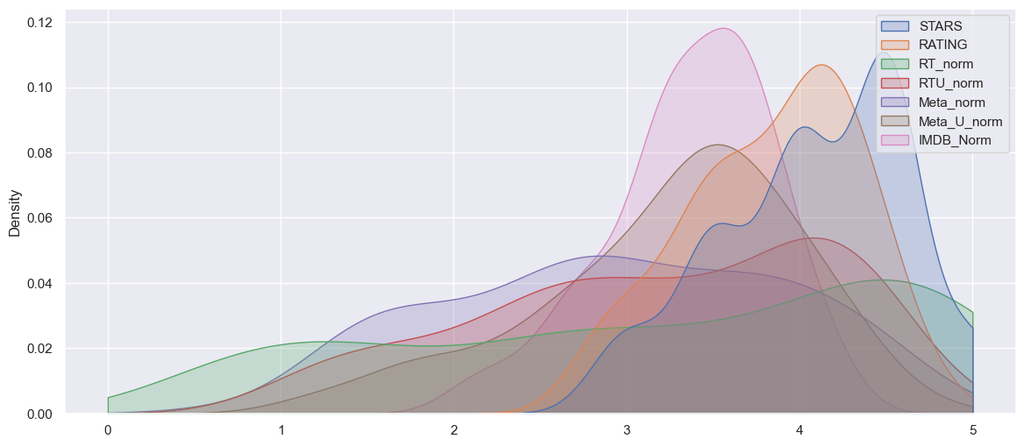

```python
sns.kdeplot(data=finalNorm, shade=True, clip=(0,5))
sns.set(rc={'figure.figsize':(6, 14)})
plt.show()
```

##### This plot clearly shows that clearly fandango has an uneven distribution and RT Critics has the most uniform distribution.

```
No artists with labels found to put in legend.  Note that artists whose label start with an underscore are ignored when legend() is called with no argument.
```

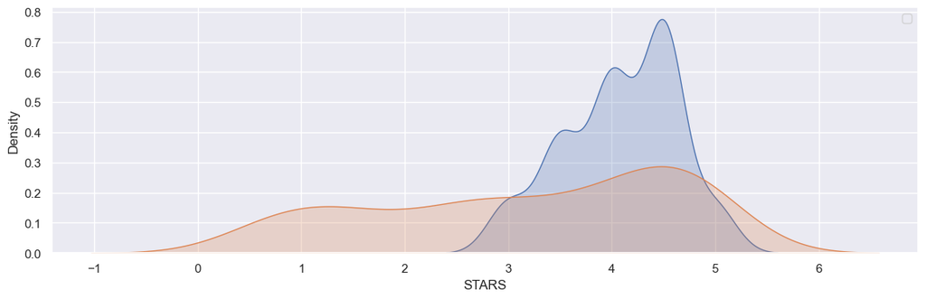

```python
sns.kdeplot(data=finalNorm, x='STARS', shade=True)
sns.kdeplot(data=finalNorm, x='RT_norm', shade=True)
sns.set(rc={'figure.figsize':(14, 4)})
plt.show()
```

##### The plot shown above is the kdeplot between RT_norm and Stars

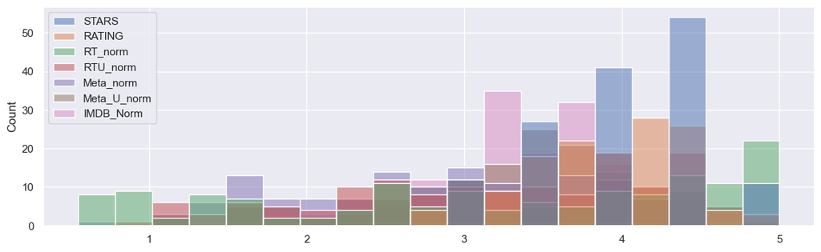

```python
sns.histplot(data=finalNorm)
```

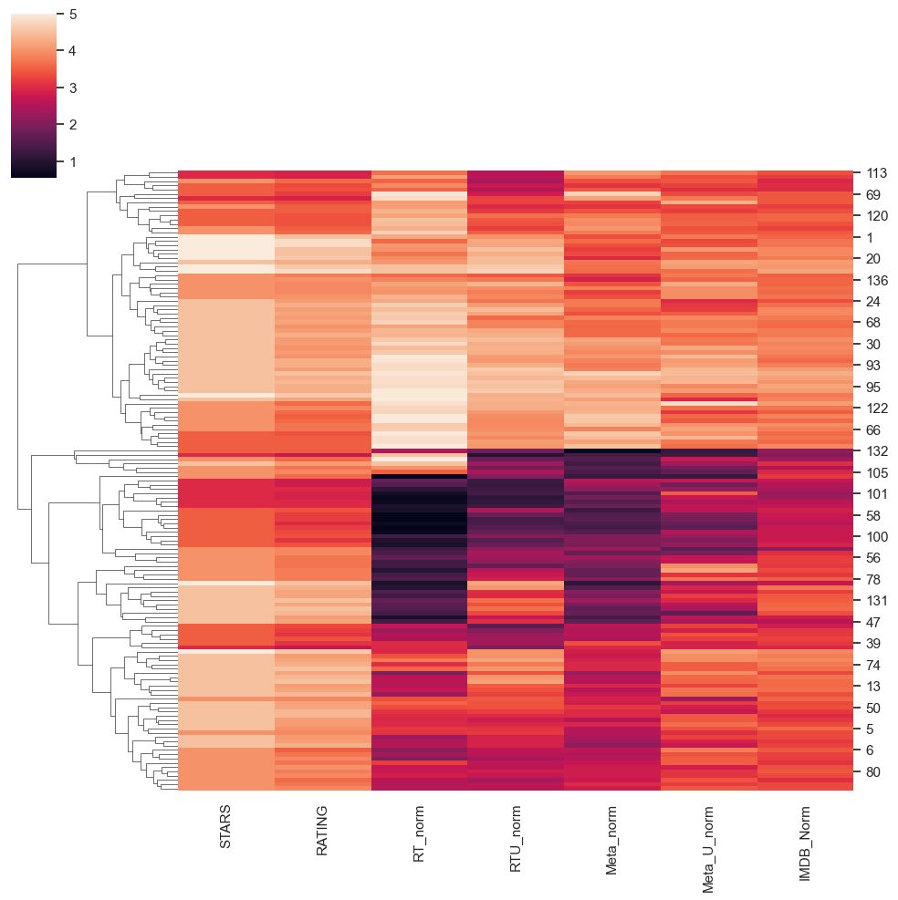

```python
sns.clustermap(data=finalNorm, col_cluster=False)
```

**By this clustermap we can clearly see that Fandango is rating movies much higher than other sites, especially considering that it is then displaying a rounded up version of the rating. Let's examine the top 10 worst movies. Based off the Rotten Tomatoes Critic Ratings, what are the top 10 lowest rated movies? What are the normalized scores across all platforms for these movies? You may need to add the FILM column back in to your DataFrame of normalized scores to see the results.**

```python
worstDf = finalNorm.nsmallest(10, 'RT_norm')
```

```python
worstDf
```

|  | STARS | RATING | RT_norm | RTU_norm | Meta_norm | Meta_U_norm | IMDB_Norm |
| --- | --- | --- | --- | --- | --- | --- | --- |
| 35 | 4.0 | 3.6 | 0.55 | 2.00 | 1.20 | 1.20 | 3.15 |
| 60 | 3.5 | 3.2 | 0.55 | 1.35 | 1.60 | 1.90 | 2.70 |
| 58 | 3.5 | 3.2 | 0.60 | 1.75 | 1.50 | 1.95 | 2.75 |
| 59 | 3.5 | 3.2 | 0.60 | 1.50 | 1.35 | 1.60 | 2.75 |
| 84 | 3.5 | 3.3 | 0.65 | 1.70 | 1.55 | 2.50 | 2.75 |
| 107 | 3.0 | 2.9 | 0.65 | 1.05 | 1.85 | 2.70 | 2.30 |
| 4 | 3.5 | 3.0 | 0.70 | 1.40 | 1.45 | 1.70 | 2.55 |
| 134 | 3.0 | 3.0 | 0.70 | 1.15 | 1.55 | 2.45 | 2.60 |
| 101 | 3.0 | 2.9 | 0.80 | 1.35 | 1.50 | 3.50 | 2.20 |
| 19 | 4.5 | 4.1 | 0.85 | 2.70 | 1.35 | 2.65 | 2.80 |

**Visualizing the distribution of ratings across all sites for the top 10 worst movies.**

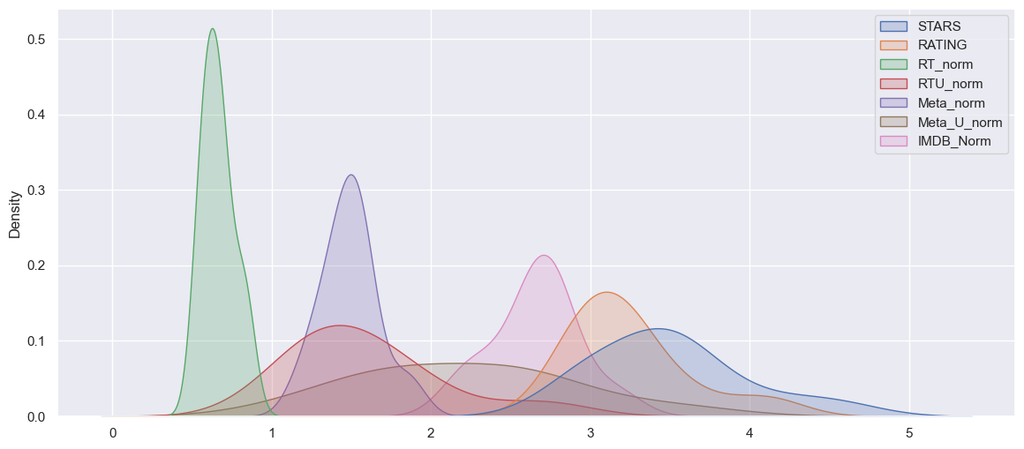

```python
sns.kdeplot(data=worstDf, shade=True)
sns.set(rc={'figure.figsize':(14,4)})
```

```python
all_sites_cpy.min()
```

```
FILM                          '71 (2015)
RottenTomatoes                         5
RottenTomatoes_User                   20
Metacritic                            13
Metacritic_User                      2.4
IMDB                                 4.0
Metacritic_user_vote_count             4
IMDB_user_vote_count                 243
ROTTEN_TOM_DIFF                      -66
ROTTEN_TOM_DIFF_ABS                    0
dtype: object
```

```python
finalNorm.min()
```

```
STARS          3.00
RATING         2.70
RT_norm        0.55
RTU_norm       1.00
Meta_norm      0.65
Meta_U_norm    1.20
IMDB_Norm      2.00
dtype: float64
```

```python
finalDf.min()
```

```
FILM                          '71 (2015)
RottenTomatoes                         5
RottenTomatoes_User                   20
Metacritic                            13
Metacritic_User                      2.4
IMDB                                 4.0
Metacritic_user_vote_count             4
IMDB_user_vote_count                 243
ROTTEN_TOM_DIFF                      -66
ROTTEN_TOM_DIFF_ABS                    0
STARS                                3.0
RATING                               2.7
VOTES                                 35
YEAR                                2014
STARS_DIFF                           0.0
RT_norm                             0.55
RTU_norm                             1.0
Meta_norm                           0.65
Meta_U_norm                          1.2
IMDB_Norm                            2.0
dtype: object
```

```python
finalNorm.min()
```

```
STARS          3.00
RATING         2.70
RT_norm        0.55
RTU_norm       1.00
Meta_norm      0.65
Meta_U_norm    1.20
IMDB_Norm      2.00
dtype: float64
```

```python
finalList2 = pd.DataFrame(data=[finalDf['FILM'], finalDf['STARS'], finalDf['RATING'], finalDf['RT_norm'], finalDf['RTU_norm'], finalDf['Meta_norm'], finalDf['Meta_U_norm'], finalDf['IMDB_Norm']])
```

```python
finalList2.min(axis=1)
```

```
FILM           '71 (2015)
STARS                 3.0
RATING                2.7
RT_norm              0.55
RTU_norm              1.0
Meta_norm            0.65
Meta_U_norm           1.2
IMDB_Norm             2.0
dtype: object
```

```python
0.55+1.0+0.65+1.2+2.0
```

```
5.4
```

```python
5.4/5
```

```
1.08
```